# Neural Network

Bronson Bagwell

2024-02-07

```r
library(caret)
library(neuralnet)
```

# 1. Read the data into R

```r
data <- read.csv("GraduateAdmission.csv")

str(data)
```

```
## 'data.frame':    400 obs. of  9 variables:
##  $ Serial.No.: int  1 2 3 4 5 6 7 8 9 10 ...
##  $ GRE       : int  337 324 316 322 314 330 321 308 302 323 ...
##  $ TOEFL     : int  118 107 104 110 103 115 109 101 102 108 ...
##  $ UnivRating: int  4 4 3 3 2 5 3 2 1 3 ...
##  $ SOP       : num  4.5 4 3 3.5 2 4.5 3 3 2 3.5 ...
##  $ LOR       : num  4.5 4.5 3.5 2.5 3 3 4 4 1.5 3 ...
##  $ CGPA      : num  9.65 8.87 8 8.67 8.21 9.34 8.2 7.9 8 8.6 ...
##  $ Research  : int  1 1 1 1 0 1 1 0 0 0 ...
##  $ Admit     : int  1 1 1 1 1 1 1 1 0 0 ...
```

```r
names(data)
```

```
## [1] "Serial.No." "GRE"        "TOEFL"      "UnivRating" "SOP"
## [6] "LOR"        "CGPA"       "Research"   "Admit"
```

# 2. Do we need to convert the categorical variables into factors? Why or why not?

We don’t convert any variables into factors because a neural network needs numeric inputs. Every column is kept numeric, and it’s essential to normalize the variables so they are on the same scale.

# 3. Prepare the data by using the Max-Min normalization method

```r
normalize <- function(x){
  return((x-min(x))/(max(x)-min(x)))
}


normdata <- as.data.frame(lapply(data,normalize))
str(normdata)
```

```
## 'data.frame':    400 obs. of  9 variables:
##  $ Serial.No.: num  0 0.00251 0.00501 0.00752 0.01003 ...
##  $ GRE       : num  0.94 0.68 0.52 0.64 0.48 0.8 0.62 0.36 0.24 0.66 ...
##  $ TOEFL     : num  0.929 0.536 0.429 0.643 0.393 ...
##  $ UnivRating: num  0.75 0.75 0.5 0.5 0.25 1 0.5 0.25 0 0.5 ...
##  $ SOP       : num  0.875 0.75 0.5 0.625 0.25 0.875 0.5 0.5 0.25 0.625 ...
##  $ LOR       : num  0.875 0.875 0.625 0.375 0.5 0.5 0.75 0.75 0.125 0.5 ...
##  $ CGPA      : num  0.913 0.663 0.385 0.599 0.452 ...
##  $ Research  : num  1 1 1 1 0 1 1 0 0 0 ...
##  $ Admit     : num  1 1 1 1 1 1 1 1 0 0 ...
```

```r
summary(normdata)
```

```
##    Serial.No.        GRE             TOEFL          UnivRating
##  Min.   :0.00   Min.   :0.0000   Min.   :0.0000   Min.   :0.0000
##  1st Qu.:0.25   1st Qu.:0.3600   1st Qu.:0.3929   1st Qu.:0.2500
##  Median :0.50   Median :0.5400   Median :0.5357   Median :0.5000
##  Mean   :0.50   Mean   :0.5362   Mean   :0.5504   Mean   :0.5219
##  3rd Qu.:0.75   3rd Qu.:0.7000   3rd Qu.:0.7143   3rd Qu.:0.7500
##  Max.   :1.00   Max.   :1.0000   Max.   :1.0000   Max.   :1.0000
##       SOP             LOR              CGPA           Research
##  Min.   :0.000   Min.   :0.0000   Min.   :0.0000   Min.   :0.0000
##  1st Qu.:0.375   1st Qu.:0.5000   1st Qu.:0.4391   1st Qu.:0.0000
##  Median :0.625   Median :0.6250   Median :0.5801   Median :1.0000
##  Mean   :0.600   Mean   :0.6131   Mean   :0.5766   Mean   :0.5475
##  3rd Qu.:0.750   3rd Qu.:0.7500   3rd Qu.:0.7252   3rd Qu.:1.0000
##  Max.   :1.000   Max.   :1.0000   Max.   :1.0000   Max.   :1.0000
##      Admit
##  Min.   :0.000
##  1st Qu.:1.000
##  Median :1.000
##  Mean   :0.775
##  3rd Qu.:1.000
##  Max.   :1.000
```

# 4. Split the data into a 80% training set and a 20% test set. Use set.seed(7332.01) for reproducibility

```r
set.seed(7332.01)
Index <- createDataPartition(as.factor(normdata$Admit),p=0.8,list=FALSE)
trdata <- normdata[Index,]  # training data set 80%
tsdata <- normdata[-Index,] # testing data set 20%
head(trdata) # Gives the first 6 rows of the training data
```

```
##    Serial.No.  GRE     TOEFL UnivRating   SOP   LOR      CGPA Research Admit
## 2 0.002506266 0.68 0.5357143       0.75 0.750 0.875 0.6634615        1     1
## 3 0.005012531 0.52 0.4285714       0.50 0.500 0.625 0.3846154        1     1
## 4 0.007518797 0.64 0.6428571       0.50 0.625 0.375 0.5993590        1     1
## 5 0.010025063 0.48 0.3928571       0.25 0.250 0.500 0.4519231        0     1
## 6 0.012531328 0.80 0.8214286       1.00 0.875 0.500 0.8141026        1     1
## 7 0.015037594 0.62 0.6071429       0.50 0.500 0.750 0.4487179        1     1
```

```r
head(tsdata) # Gives the first 6 rows of the testing data
```

```
##    Serial.No.  GRE      TOEFL UnivRating   SOP   LOR      CGPA Research Admit
## 1  0.00000000 0.94 0.92857143       0.75 0.875 0.875 0.9134615        1     1
## 14 0.03258145 0.34 0.60714286       0.50 0.750 0.500 0.3846154        1     0
## 22 0.05263158 0.70 0.78571429       0.75 0.500 0.250 0.5128205        0     1
## 26 0.06265664 1.00 1.00000000       1.00 0.875 0.875 0.8974359        1     1
## 29 0.07017544 0.10 0.03571429       0.00 0.250 0.250 0.1282051        0     0
## 33 0.08020050 0.96 0.92857143       0.75 0.500 0.875 0.8333333        1     1
```

```r
names(normdata)
```

```
## [1] "Serial.No." "GRE"        "TOEFL"      "UnivRating" "SOP"
## [6] "LOR"        "CGPA"       "Research"   "Admit"
```

# 5. What are the top 3 predictors (features) that you identified using importance plot according to the MeanDecreaseGini for the Random Forest-Bagging model?

1. CGPA
2. GRE
3. SOP

# 6. Find the neural network (nn) model with 1 hidden layer to predict Admit using the top 3 predictors you stated in the previous question. Report overall accuracy, misclassification, sensitivity and specificity for the test data. Use set.seed(7332.01) for reproducibility.

```r
set.seed(7332.01)
nnmodel <- neuralnet(Admit~ CGPA+GRE+SOP,
                     trdata,
                     hidden=1,
                     err.fct = "ce",
                     rep=5,
                     lifesign = "full",
                     linear.output = FALSE)  # Neural Network Model
```

```
## hidden: 1    thresh: 0.01    rep: 1/5    steps:    1000  min thresh: 0.125630655531034
##                                                    2000  min thresh: 0.0699011702847269
##                                                    3000  min thresh: 0.0543005725893937
##                                                    4000  min thresh: 0.0384528690513042
##                                                    5000  min thresh: 0.0384528690513042
##                                                    6000  min thresh: 0.0319223657491316
##                                                    7000  min thresh: 0.0319223657491316
##                                                    8000  min thresh: 0.0234800793211429
##                                                    9000  min thresh: 0.0222639922197811
##                                                   10000  min thresh: 0.0222639922197811
##                                                   11000  min thresh: 0.0222639922197811
##                                                   12000  min thresh: 0.0208315141514794
##                                                   13000  min thresh: 0.0208315141514794
##                                                   14000  min thresh: 0.0162623117995304
##                                                   15000  min thresh: 0.0113833311830324
```

[output cut: 95 more lines]

```r
# Predicting test data.
best1 <- which.min(nnmodel$result.matrix["error", ])
pred_clannts <- predict(nnmodel, tsdata, rep = best1)
```

```r
# Gives predicted probabilities and others
head(pred_clannts) # shows the first 6 predicted probabilities from test data
```

```
##          [,1]
## 1  0.99748589
## 14 0.60943082
## 22 0.91366735
## 26 0.99755033
## 29 0.01367895
## 33 0.99474643
```

```r
head(tsdata[1:6,])  # shows the first 6  rows of the test data
```

```
##    Serial.No.  GRE      TOEFL UnivRating   SOP   LOR      CGPA Research Admit
## 1  0.00000000 0.94 0.92857143       0.75 0.875 0.875 0.9134615        1     1
## 14 0.03258145 0.34 0.60714286       0.50 0.750 0.500 0.3846154        1     0
## 22 0.05263158 0.70 0.78571429       0.75 0.500 0.250 0.5128205        0     1
## 26 0.06265664 1.00 1.00000000       1.00 0.875 0.875 0.8974359        1     1
## 29 0.07017544 0.10 0.03571429       0.00 0.250 0.250 0.1282051        0     0
## 33 0.08020050 0.96 0.92857143       0.75 0.500 0.875 0.8333333        1     1
```

```r
pred_classnnts<- ifelse(pred_clannts>0.5,1,0) # Assigning probabilities to classes
conf_clannts<-table(Predicted=pred_classnnts,Actual=tsdata$Admit) # confusion matrix from nnmodel
conf_clannts  # confusion Matrix from nn model
```

```
##          Actual
## Predicted  0  1
##         0 11  3
##         1  7 59
```

```r
### Overall accuracy and misclasification in the test data
ts_oacc <- sum(diag(conf_clannts))/sum(conf_clannts)  # Overall accuracy
ts_oacc  # test overall accuracy
```

```
## [1] 0.875
```

```r
1-ts_oacc # test misclasification
```

```
## [1] 0.125
```

```r
# Sensitivity and Specificity via caret
cm <- caret::confusionMatrix(factor(pred_classnnts, levels = c(0, 1)),
                             factor(tsdata$Admit, levels = c(0, 1)),
                             positive = "1")
cm$byClass["Sensitivity"]
```

```
## Sensitivity
##   0.9516129
```

```r
cm$byClass["Specificity"]
```

```
## Specificity
##   0.6111111
```

Overall Accuracy .875

Misclassification .125

Sensitivity .952

specificity .611

# 7. Plot the nn model found in the previous question.

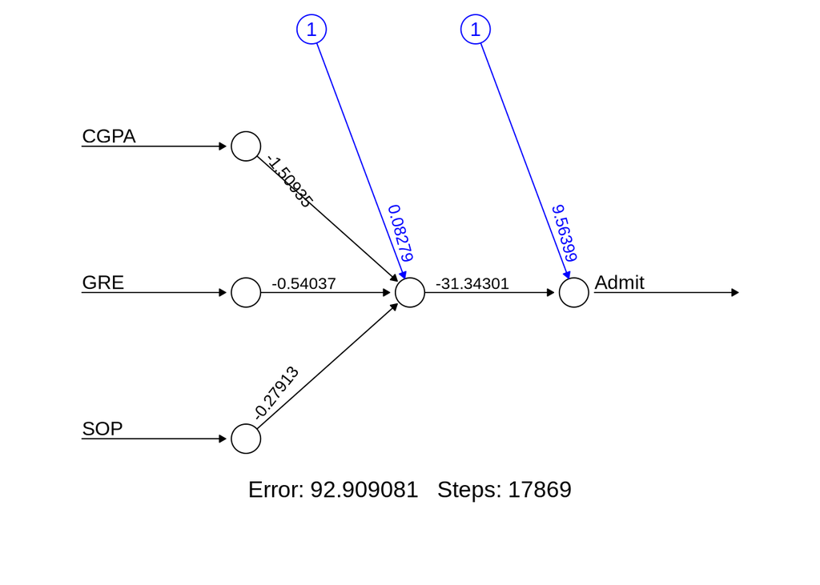

```r
plot(nnmodel,"best")
```

# 8. Attempt different parameters of the hidden layers (number of hidden layers and number of nodes). Report the model, plot, the overall accuracy, misclassification, sensitivity and specificity. Use set.seed(7332.01) for reproducibility

One Hidden Layer, Two Neurons

```r
nnmodel2 <- neuralnet(Admit~ CGPA+GRE+SOP,
                     trdata,
                     hidden=2,
                     err.fct = "ce",
                     rep=5,
                     lifesign = "full",
                     linear.output = FALSE)  # Neural Network Model
```

```
## hidden: 2    thresh: 0.01    rep: 1/5    steps:    1000  min thresh: 0.0823621055885386
##                                                    2000  min thresh: 0.0505275771225486
##                                                    3000  min thresh: 0.0492250013543829
##                                                    4000  min thresh: 0.0480966087578389
##                                                    5000  min thresh: 0.0387670105115815
##                                                    6000  min thresh: 0.0357158241700688
##                                                    7000  min thresh: 0.0324436956891141
##                                                    8000  min thresh: 0.0261120112736277
##                                                    9000  min thresh: 0.0218331049645215
##                                                   10000  min thresh: 0.0199639217520726
##                                                   11000  min thresh: 0.0184213998502525
##                                                   12000  min thresh: 0.0167473249685445
##                                                   13000  min thresh: 0.0167473249685445
##                                                   14000  min thresh: 0.0142011288452324
##                                                   15000  min thresh: 0.0134950123259588
```

[output cut: 142 more lines]

```r
# Predicting test data.
best2 <- which.min(nnmodel2$result.matrix["error", ])
pred_clannts2 <- predict(nnmodel2, tsdata, rep = best2)
```

```r
# Gives predicted probabilities and others
head(pred_clannts2) # shows the first 6 predicted probabilities from test data
```

```
##            [,1]
## 1  9.996623e-01
## 14 5.443369e-01
## 22 9.346307e-01
## 26 9.997086e-01
## 29 2.239337e-08
## 33 9.993653e-01
```

```r
head(tsdata[1:6,])  # shows the first 6  rows of the test data
```

```
##    Serial.No.  GRE      TOEFL UnivRating   SOP   LOR      CGPA Research Admit
## 1  0.00000000 0.94 0.92857143       0.75 0.875 0.875 0.9134615        1     1
## 14 0.03258145 0.34 0.60714286       0.50 0.750 0.500 0.3846154        1     0
## 22 0.05263158 0.70 0.78571429       0.75 0.500 0.250 0.5128205        0     1
## 26 0.06265664 1.00 1.00000000       1.00 0.875 0.875 0.8974359        1     1
## 29 0.07017544 0.10 0.03571429       0.00 0.250 0.250 0.1282051        0     0
## 33 0.08020050 0.96 0.92857143       0.75 0.500 0.875 0.8333333        1     1
```

```r
### Part II vii) ###
pred_classnnts2 <- ifelse(pred_clannts2>0.5,1,0) # Assigning probabilities to classes
conf_clannts2<-table(Predicted=pred_classnnts2,Actual=tsdata$Admit) # confusion matrix from nnmodel
conf_clannts2  # confusion Matrix from nn model
```

```
##          Actual
## Predicted  0  1
##         0 11  3
##         1  7 59
```

```r
### Overall accuracy and misclasification in the test data
ts_oacc2 <- sum(diag(conf_clannts2))/sum(conf_clannts2)  # Overall accuracy
ts_oacc2  # test overall accuracy
```

```
## [1] 0.875
```

```r
1-ts_oacc2 # test misclasification
```

```
## [1] 0.125
```

```r
# Sensitivity and Specificity via caret
cm2 <- caret::confusionMatrix(factor(pred_classnnts2, levels = c(0, 1)),
                              factor(tsdata$Admit, levels = c(0, 1)),
                              positive = "1")
cm2$byClass["Sensitivity"]
```

```
## Sensitivity
##   0.9516129
```

```r
cm2$byClass["Specificity"]
```

```
## Specificity
##   0.6111111
```

Overall Accuracy .875

Misclassification .125

Sensitivity .952

specificity .611

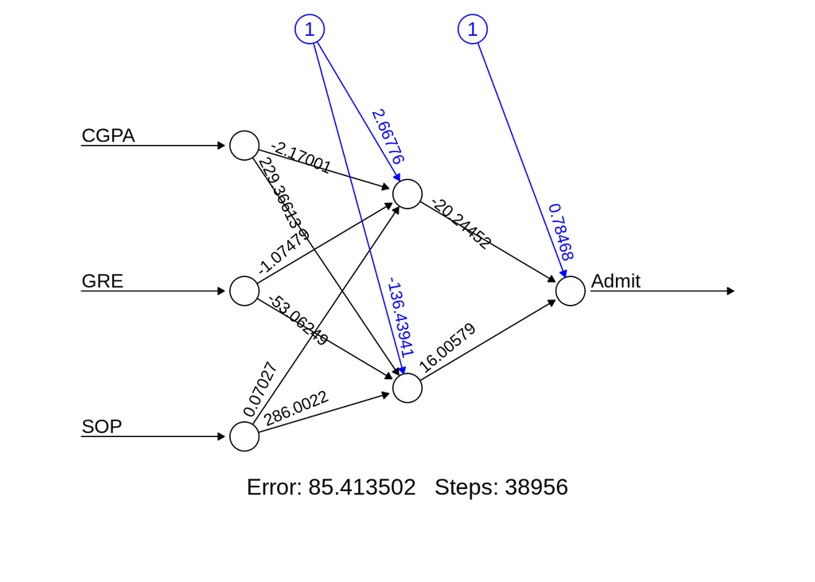

```r
plot(nnmodel2,"best")
```

One Hidden Layer, Three Neurons

```r
nnmodel3 <- neuralnet(Admit~ CGPA+GRE+SOP,
                     trdata,
                     hidden=c(3),
                     err.fct = "ce",
                     rep=5,
                     lifesign = "full",
                     linear.output = FALSE)  # Neural Network Model
```

```
## hidden: 3    thresh: 0.01    rep: 1/5    steps:    1000  min thresh: 0.0482085661332574
##                                                    2000  min thresh: 0.0482085661332574
##                                                    3000  min thresh: 0.0482085661332574
##                                                    4000  min thresh: 0.0482085661332574
##                                                    5000  min thresh: 0.0482085661332574
##                                                    6000  min thresh: 0.036259428892468
##                                                    7000  min thresh: 0.0276321173869514
##                                                    8000  min thresh: 0.0154612858270102
##                                                    9000  min thresh: 0.0131931758591405
##                                                   10000  min thresh: 0.0101059794377466
##                                                   10187  error: 80.09834 time: 1.92 secs
## hidden: 3    thresh: 0.01    rep: 2/5    steps:    1000  min thresh: 0.0670569640870351
##                                                    2000  min thresh: 0.0670569640870351
##                                                    3000  min thresh: 0.0670569640870351
##                                                    4000  min thresh: 0.0670569640870351
```

[output cut: 67 more lines]

```r
# Predicting test data.
best3 <- which.min(nnmodel3$result.matrix["error", ])
pred_clannts3 <- predict(nnmodel3, tsdata, rep = best3)
```

```r
# Gives predicted probabilities and others
head(pred_clannts3) # shows the first 6 predicted probabilities from test data
```

```
##         [,1]
## 1  0.9810463
## 14 0.1301215
## 22 0.9718862
## 26 0.9788639
## 29 0.0000000
## 33 0.9792781
```

```r
head(tsdata[1:6,])  # shows the first 6  rows of the test data
```

```
##    Serial.No.  GRE      TOEFL UnivRating   SOP   LOR      CGPA Research Admit
## 1  0.00000000 0.94 0.92857143       0.75 0.875 0.875 0.9134615        1     1
## 14 0.03258145 0.34 0.60714286       0.50 0.750 0.500 0.3846154        1     0
## 22 0.05263158 0.70 0.78571429       0.75 0.500 0.250 0.5128205        0     1
## 26 0.06265664 1.00 1.00000000       1.00 0.875 0.875 0.8974359        1     1
## 29 0.07017544 0.10 0.03571429       0.00 0.250 0.250 0.1282051        0     0
## 33 0.08020050 0.96 0.92857143       0.75 0.500 0.875 0.8333333        1     1
```

```r
### Part II vii) ###
pred_classnnts3 <- ifelse(pred_clannts3>0.5,1,0) # Assigning probabilities to classes
conf_clannts3<-table(Predicted=pred_classnnts3,Actual=tsdata$Admit) # confusion matrix from nnmodel
conf_clannts3  # confusion Matrix from nn model
```

```
##          Actual
## Predicted  0  1
##         0 12  4
##         1  6 58
```

```r
### Overall accuracy and misclasification in the test data
ts_oacc3 <- sum(diag(conf_clannts3))/sum(conf_clannts3)  # Overall accuracy
ts_oacc3  # test overall accuracy
```

```
## [1] 0.875
```

```r
1-ts_oacc3 # test misclasification
```

```
## [1] 0.125
```

```r
# Sensitivity and Specificity via caret
cm3 <- caret::confusionMatrix(factor(pred_classnnts3, levels = c(0, 1)),
                              factor(tsdata$Admit, levels = c(0, 1)),
                              positive = "1")
cm3$byClass["Sensitivity"]
```

```
## Sensitivity
##   0.9354839
```

```r
cm3$byClass["Specificity"]
```

```
## Specificity
##   0.6666667
```

Overall Accuracy .875

Misclassification .125

Sensitivity .935

specificity .667

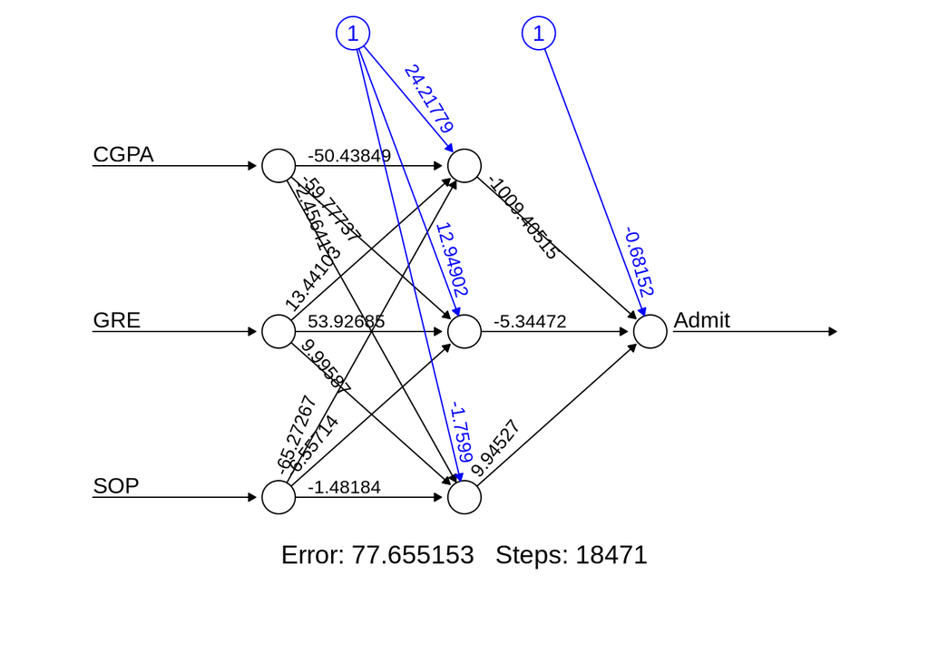

```r
plot(nnmodel3,"best")
```

# 9. The same data and the same test set were used to predict Admit in the Classification_Model and Tree_Based_Models projects. Compare the test misclassification error from the decision tree, Random Forest, Random Forest-Bagging, the logistic model and neural network model. Which model is best?

Decision Tree .1375

Random Forest .15

Random Forest-Bagging .1375

Logistic Model .1125

Neural Network (1, 2 and 3 hidden neurons) .125

Best is still the Logistic Model, by one test observation (9 vs 10 errors out of 80)

# 10.

Bronson Bagwell